# Building a Prediction Model for the LendingClub Loans Dataset

## Preliminary Analysis, Visualization, and Feature Engineering

After conducting a preliminary data exploration, we got a much better sense of our dataset. Based on what we learned, we dropped further covariates and re-categorized some of the variables which we will explain in this section.

In our prediction model, we decided to predict loan status. We dichotomized loan status into “Good” and “Bad” based on the following criteria: **Good**  
1. Fully Paid  
2. Current

**Bad**  
1. Default  
2. Charged Off  
3. Late (16-30 days)  
4. Late (31-120 days)

Since we are predicting loan status using our model, we decided to drop records with `loan_status` with values `Issued`:

```r
query <- loan.dat$loan_status != 'Issued'
loan.dat <- loan.dat[query, ]

loan.dat$loan_status_bin <- NA
query = loan.dat$loan_status == 'Fully Paid' | loan.dat$loan_status == 'Current'
loan.dat$loan_status_bin[query] = 'Good'

query = loan.dat$loan_status == 'Charged Off' | loan.dat$loan_status == 'Default' |
  loan.dat$loan_status == 'Late (16-30 days)' | loan.dat$loan_status == 'Late (31-120 days)'
loan.dat$loan_status_bin[query] = 'Bad'

query <- !is.na(loan.dat$loan_status_bin)
loan.dat <- loan.dat[query, ]

loan.dat$loan_status_bin = as.factor(loan.dat$loan_status_bin)
summary(loan.dat$loan_status_bin)
```

```
##    Bad   Good
##  60415 809500
```

We also converted `funded_amnt_inv` to be percent funded amount by investors `perc_funded_amnt_inv` and only use the year from issue date (`issue_d`):

```r
loan.dat <- loan.dat %>%
  mutate(perc_funded_amnt_inv = funded_amnt_inv/funded_amnt,
         issue_d = as.character(issue_d),
         term = as.character(term)) %>%
  mutate(year = as.numeric(str_sub(issue_d, start = -4)))
```

We reclassified a 36 month loan to “Short” and a 60 month loan to “Long”.

```r
query <- loan.dat$term == ' 36 months'
loan.dat$term[query] = 'Short'
loan.dat$term[!query] = 'Long'
loan.dat$term = as.factor(loan.dat$term)
```

We also dichotomized `tot_coll_amt` to 0 and greater than 0 (and replaced the missing values to zero):

```r
query.na <- is.na(loan.dat$tot_coll_amt)
if (sum(query.na) >0){
  loan.dat$tot_coll_amt[query.na] = 0
}
loan.dat <- loan.dat %>%
  mutate(tot_coll_amt_gt0 = as.factor(tot_coll_amt > 0.))
```

We recoded the `grade` variable to be ordinal:

```r
loan.dat$grade_ordinal <- NA
loan.dat <- loan.dat %>%
  mutate(grade = as.character(grade))
grades <- c('A', 'B', 'C', 'D', 'E', 'F', 'G')

counter = 1
for (grade in grades){

  query <- loan.dat$grade == grade
  if (sum(query) > 0){
    loan.dat$grade_ordinal[query] = as.numeric(counter)
  }
  counter = counter + 1
}

sum(is.na(loan.dat$grade_ordinal))
```

```
## [1] 0
```

We also recoded the `emp_length` variable to be ordinal (and removed records with no employment length information):

```r
loan.dat$emp_length_ordinal <- NA
loan.dat <- loan.dat %>%
  mutate(emp_length = as.character(emp_length))

loan.dat <- loan.dat %>% filter(!(emp_length == 'n/a'))

emp_lengths <- c('< 1 year', '1 year',
                 '2 years', '3 years',
                 '4 years', '5 years',
                 '6 years', '7 years',
                 '8 years', '9 years',
                 '10+ years')

counter = 1
for (emp_length in emp_lengths){

  query <- loan.dat$emp_length == emp_length
  if (sum(query) > 0){
    loan.dat$emp_length_ordinal[query] = as.numeric(counter)
  }
  counter = counter + 1
}

sum(is.na(loan.dat$emp_length_ordinal))
```

```
## [1] 0
```

```r
predictors <- c('loan_amnt', 'funded_amnt',
                'grade_ordinal',
                'emp_length_ordinal', 'home_ownership',
                'annual_inc', 'verification_status',
                'purpose',
                'addr_state', 'dti',
                'delinq_2yrs', 'inq_last_6mths',
                'open_acc', 'pub_rec',
                'revol_bal', 'revol_util',
                'total_acc', 'initial_list_status',
                'application_type', 'acc_now_delinq',
                'tot_coll_amt_gt0', 'tot_cur_bal',
                'total_rev_hi_lim', 'perc_funded_amnt_inv',
                'term')
predictors
```

```
##  [1] "loan_amnt"            "funded_amnt"          "grade_ordinal"
##  [4] "emp_length_ordinal"   "home_ownership"       "annual_inc"
##  [7] "verification_status"  "purpose"              "addr_state"
## [10] "dti"                  "delinq_2yrs"          "inq_last_6mths"
## [13] "open_acc"             "pub_rec"              "revol_bal"
## [16] "revol_util"           "total_acc"            "initial_list_status"
## [19] "application_type"     "acc_now_delinq"       "tot_coll_amt_gt0"
## [22] "tot_cur_bal"          "total_rev_hi_lim"     "perc_funded_amnt_inv"
## [25] "term"
```

```r
outcome <- c('loan_status_bin')

loan.dat <- loan.dat[, c(outcome, predictors)]
```

We also did a simple uni-variate analysis of the covariates using histograms and boxplots:

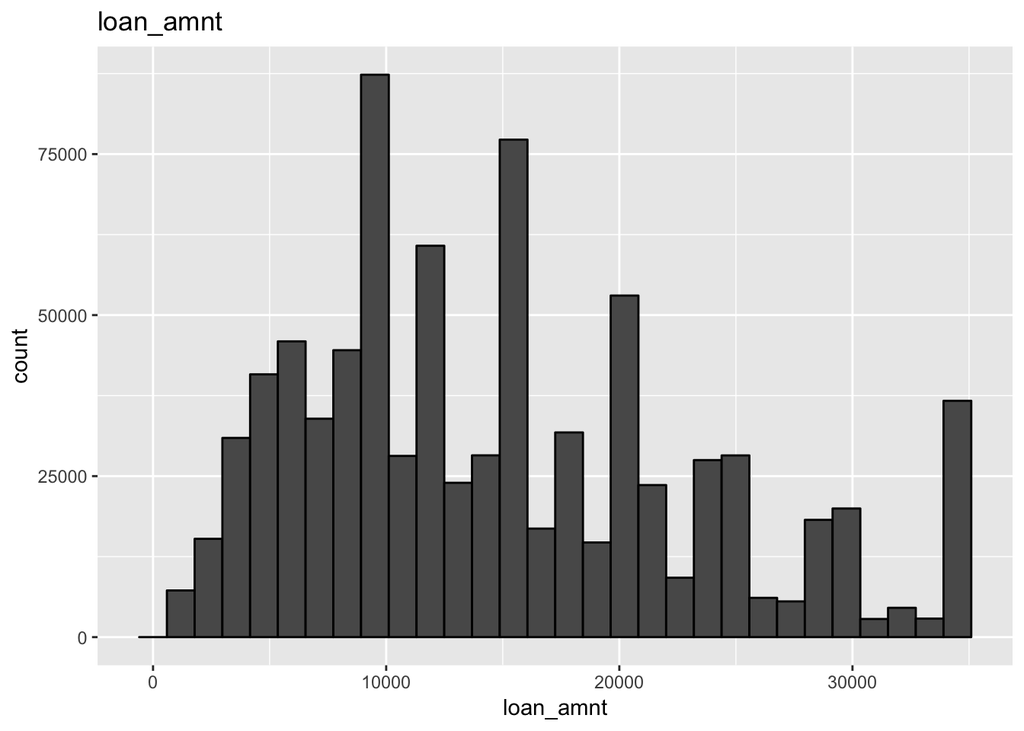

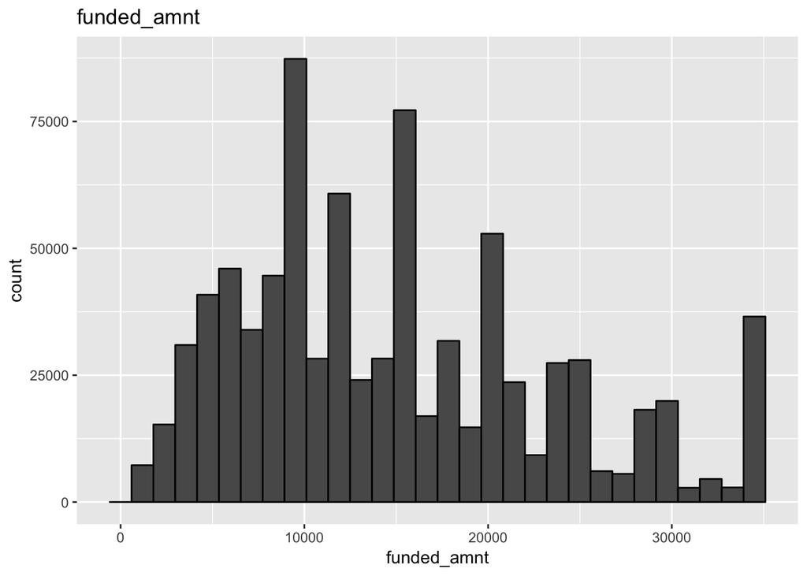

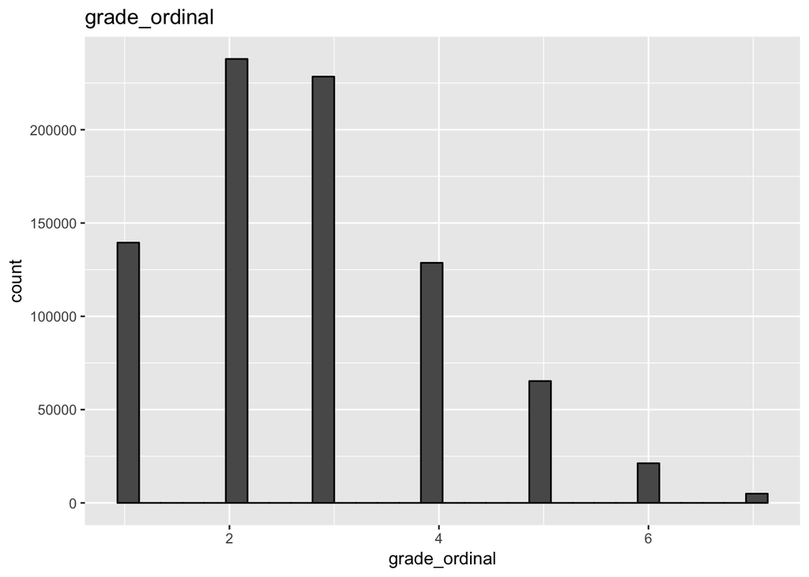

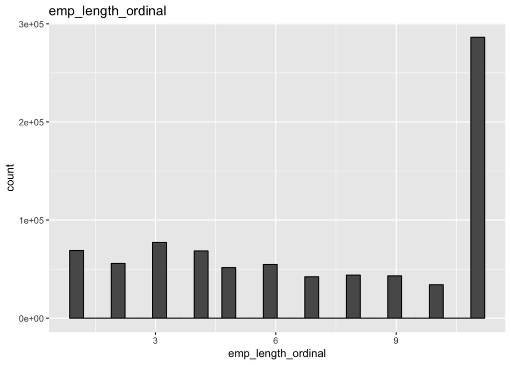

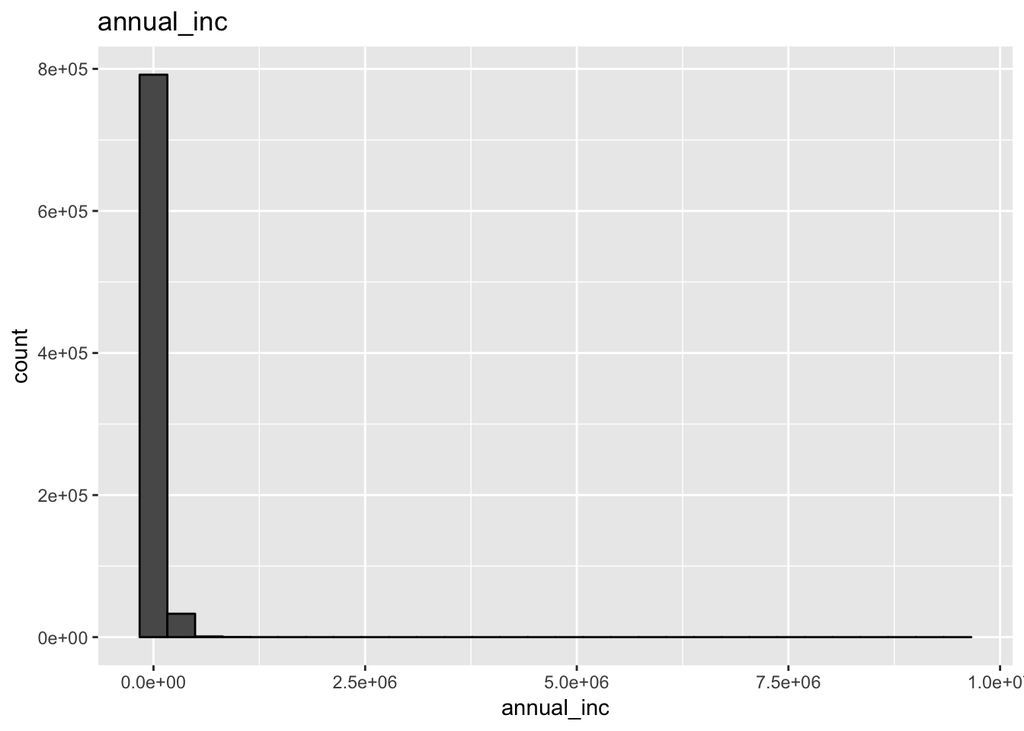

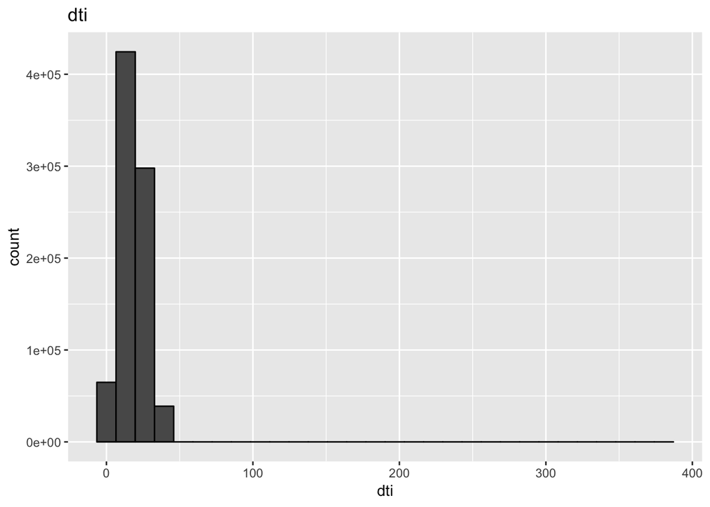

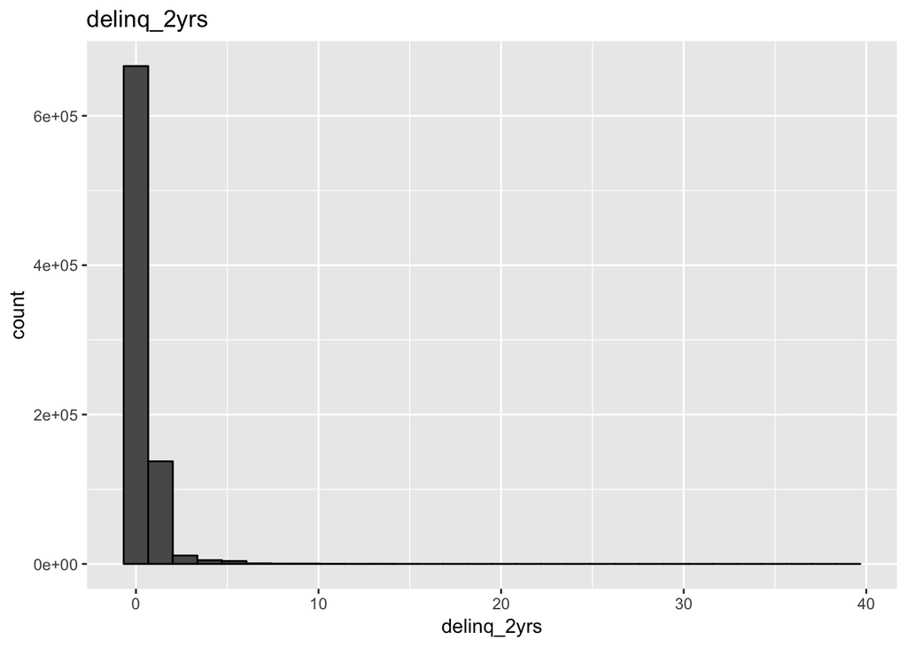

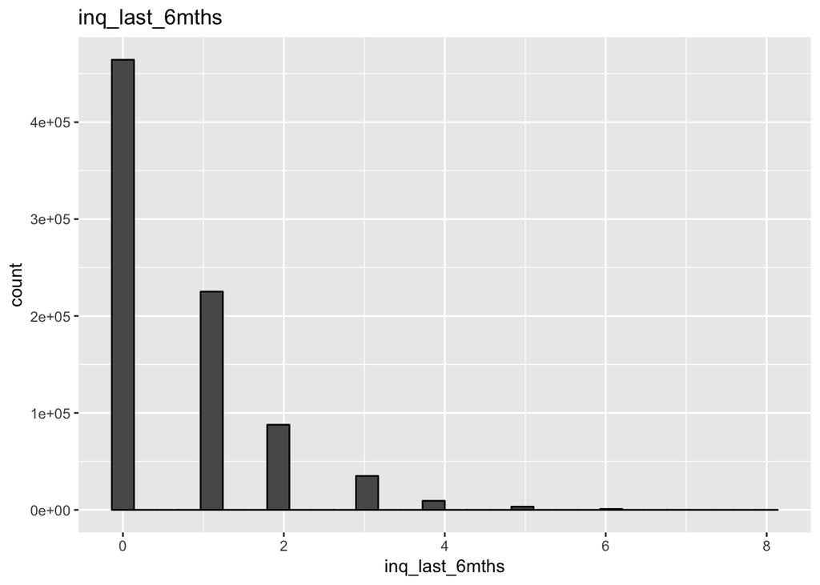

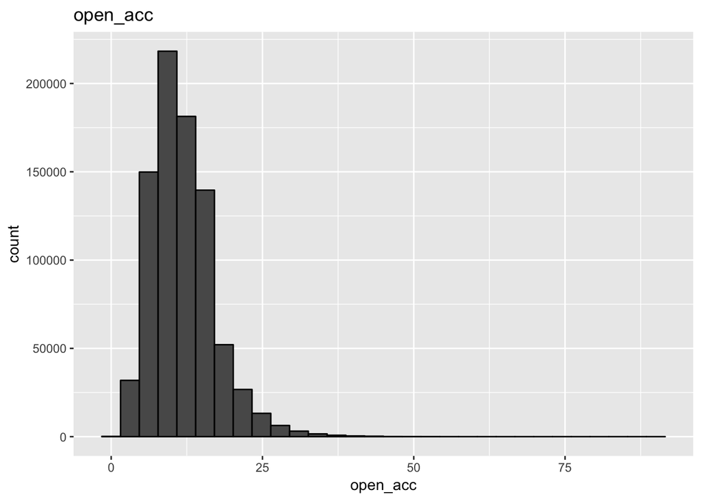

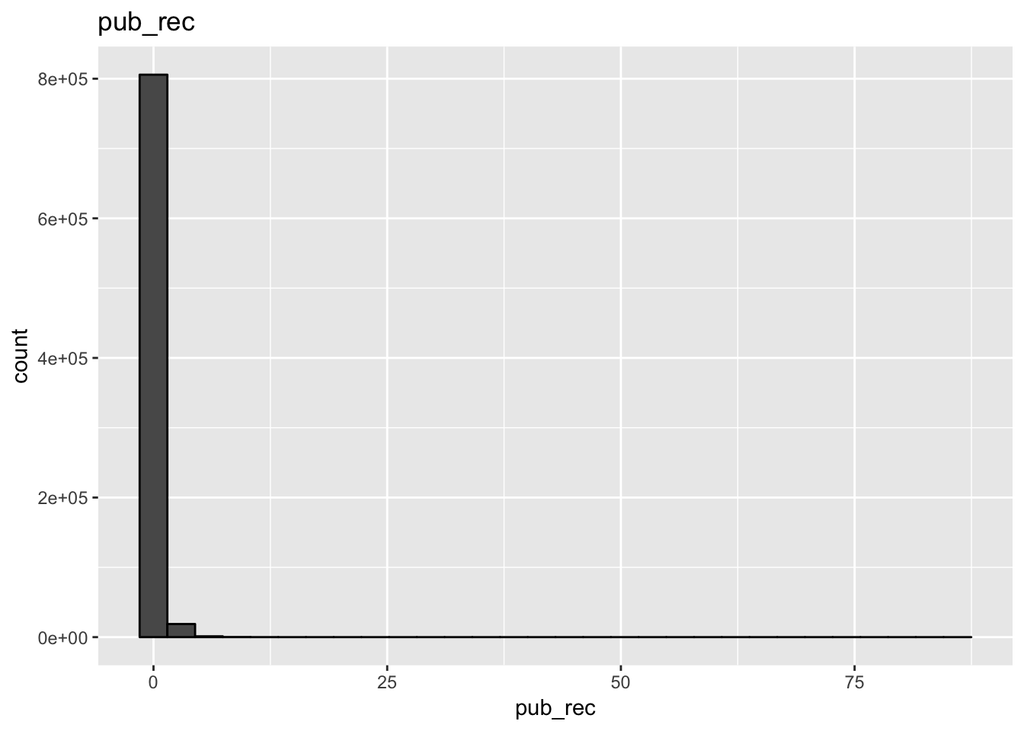

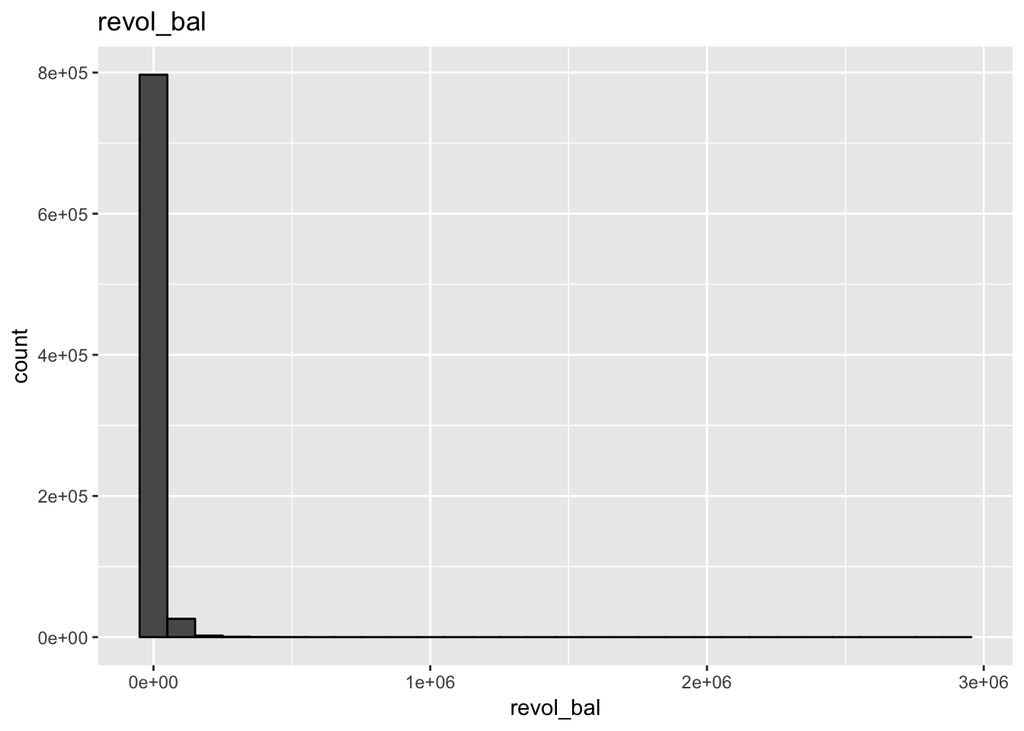

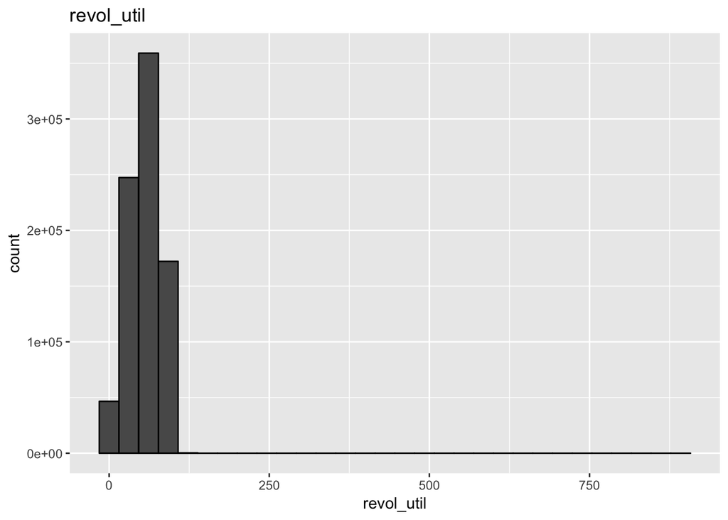

[5 more figures not shown]

```r
meta_loans <- funModeling::df_status(loan.dat, print_results = FALSE)
numeric_cols <- meta_loans$variable[meta_loans$type == 'numeric']

for (col_name in numeric_cols){
  plt <- loan.dat %>% ggplot(aes(loan.dat[, col_name])) +
    geom_histogram(color = "black") +
    ggtitle(col_name) + labs(x=col_name)
  print(plt)
}
```

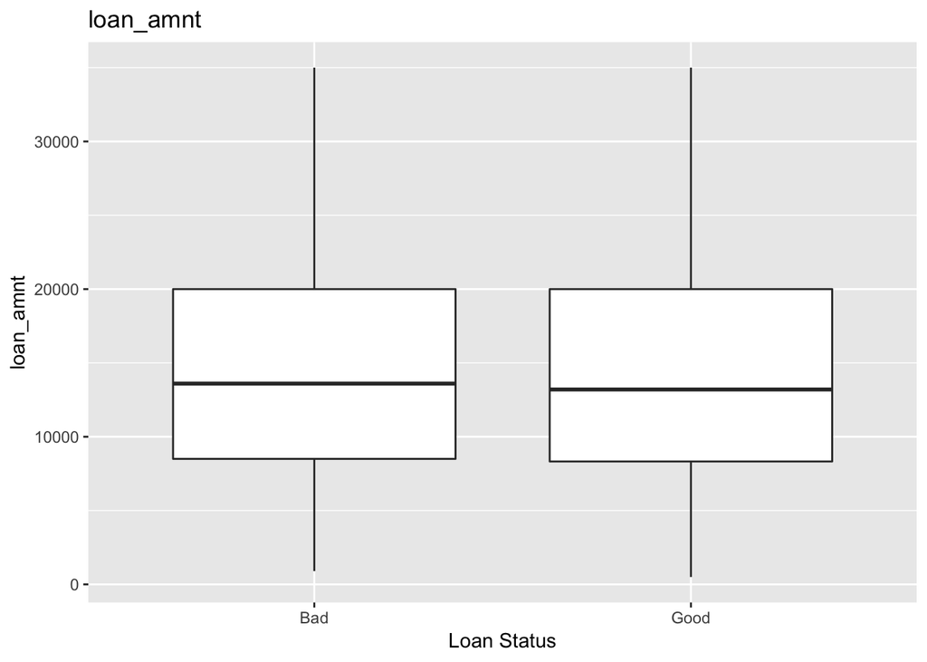

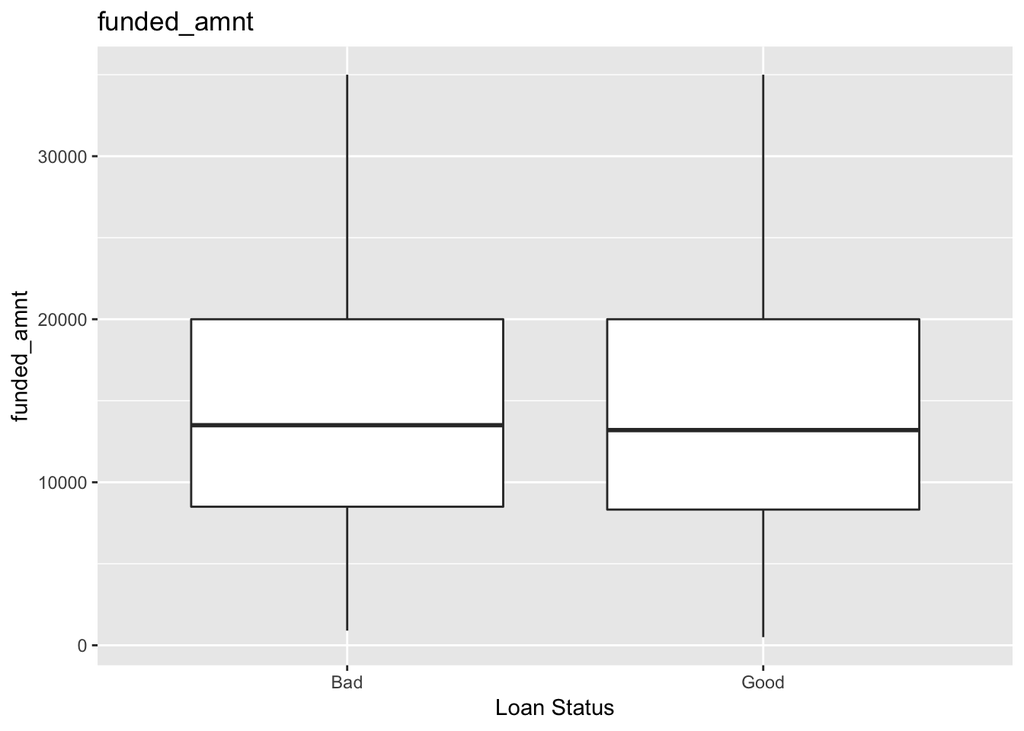

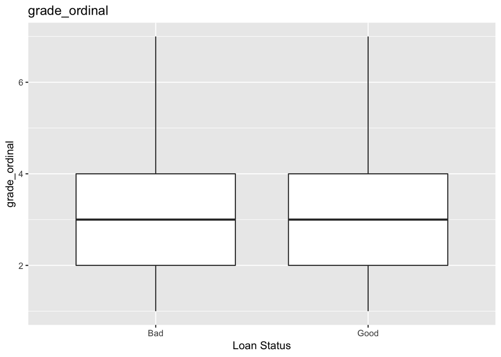

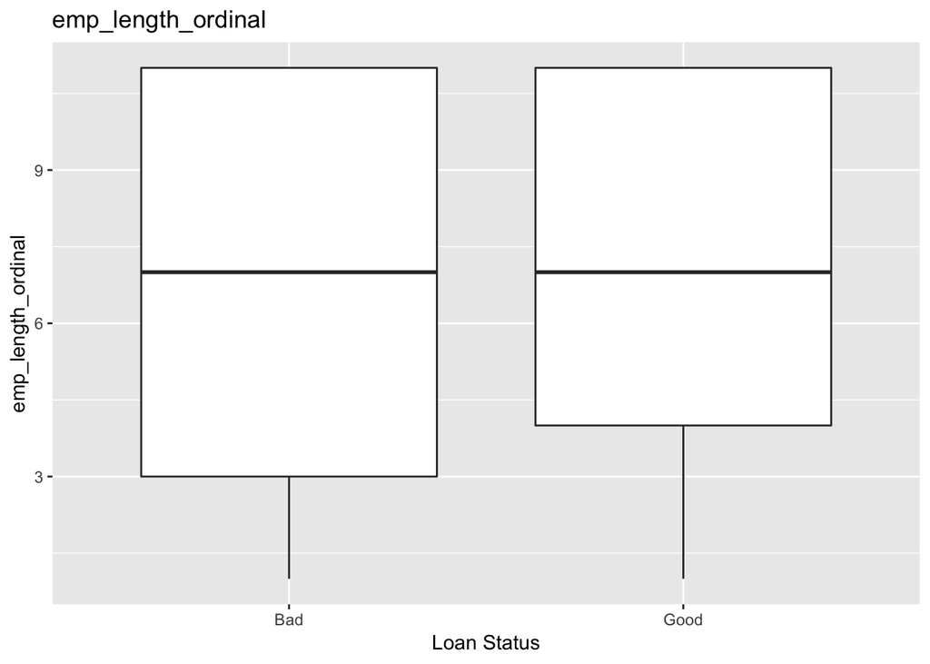

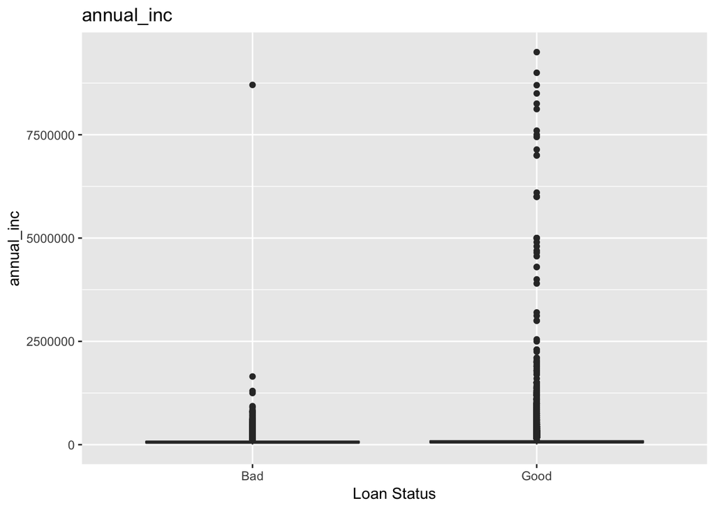

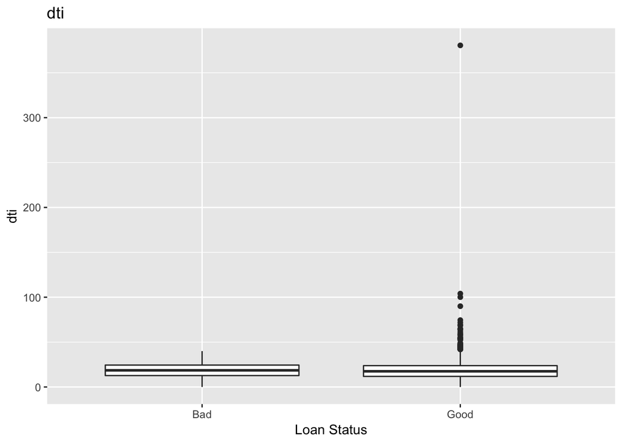

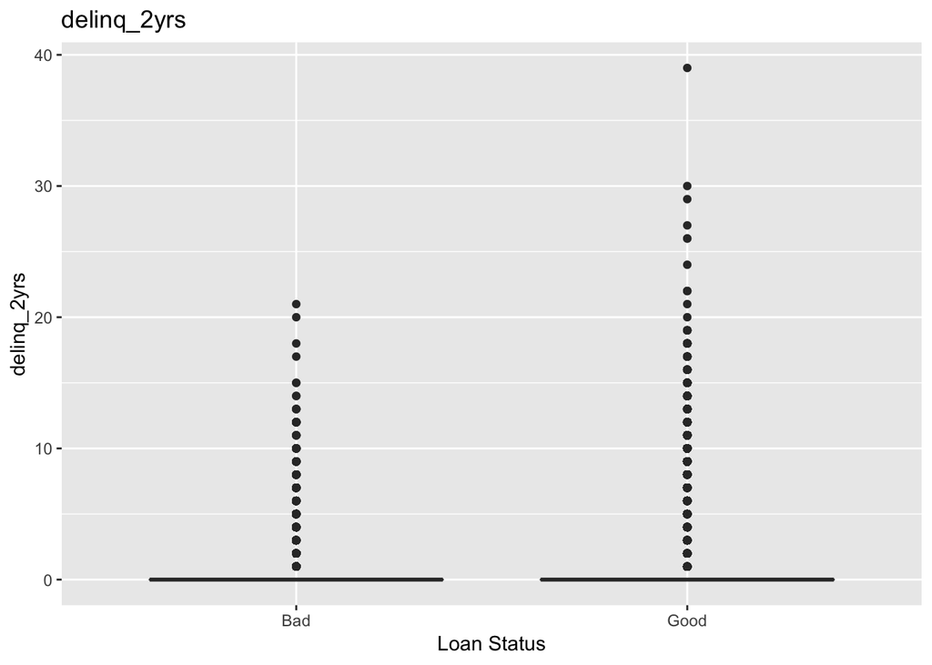

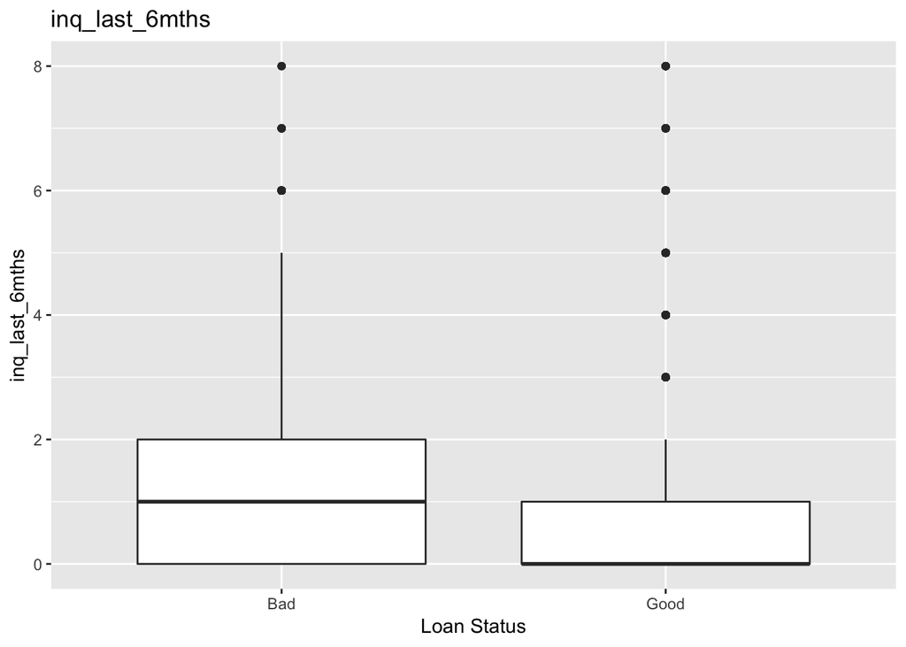

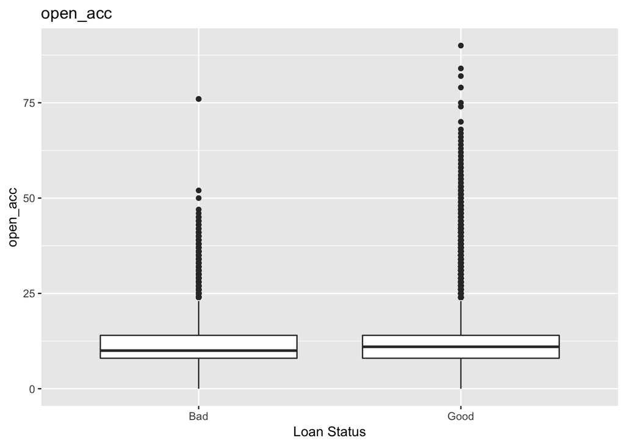

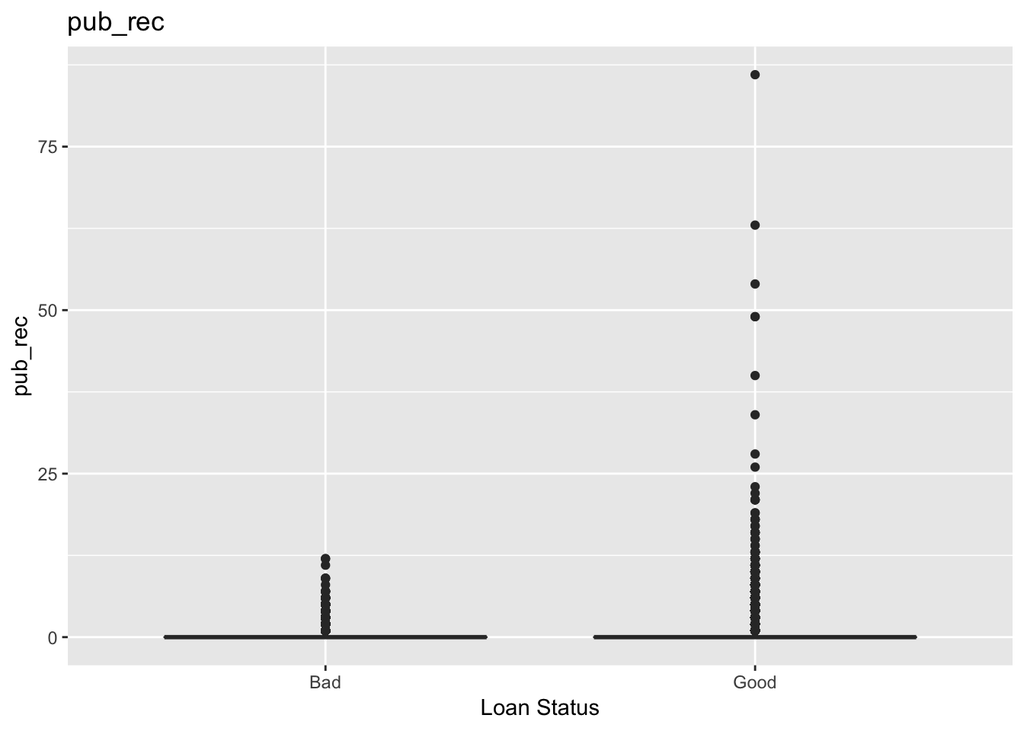

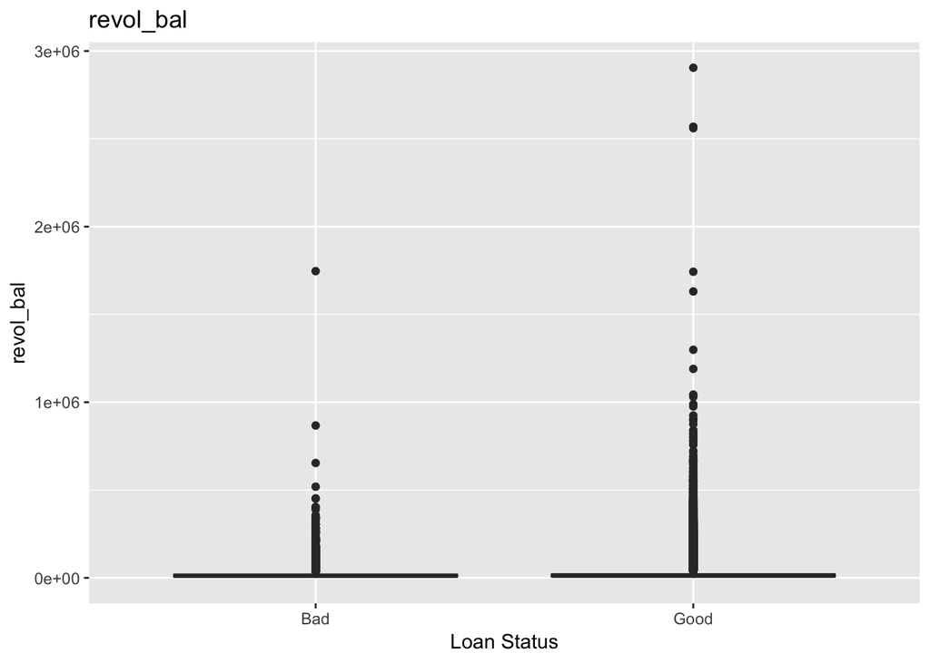

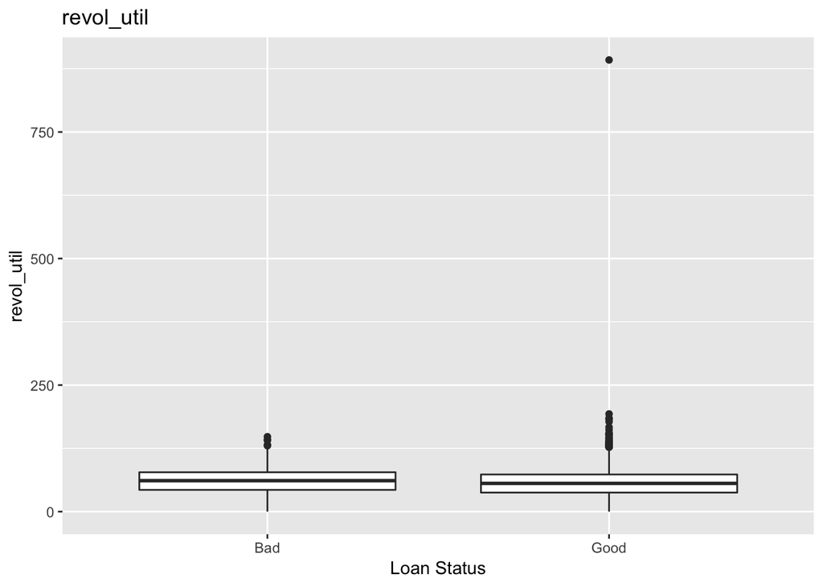

[5 more figures not shown]

```r
for (col_name in numeric_cols){
  plt <- loan.dat %>% ggplot(aes(x=loan_status_bin, loan.dat[, col_name])) +
    geom_boxplot() +
    ggtitle(col_name) + labs(x='Loan Status', y=col_name)
  print(plt)
}
```

At this point, we still had a few records with missing data. We initially tried imputing these values using the `mice` package but due to computational reasons, we decided to drop this idea.

```r
meta_loans <- funModeling::df_status(loan.dat, print_results = FALSE)
meta_loans[order(-meta_loans$p_na),]
```

|  | variable | q_zeros | p_zeros | q_na | p_na | q_inf | p_inf | type | unique |
| --- | --- | --- | --- | --- | --- | --- | --- | --- | --- |
| 23 | tot_cur_bal | 111 | 0.01 | 65436 | 7.92 | 0 | 0 | numeric | 319073 |
| 24 | total_rev_hi_lim | 277 | 0.03 | 65436 | 7.92 | 0 | 0 | numeric | 20294 |
| 17 | revol_util | 3233 | 0.39 | 442 | 0.05 | 0 | 0 | numeric | 1341 |
| 1 | loan_status_bin | 0 | 0.00 | 0 | 0.00 | 0 | 0 | factor | 2 |
| 2 | loan_amnt | 0 | 0.00 | 0 | 0.00 | 0 | 0 | numeric | 1368 |
| 3 | funded_amnt | 0 | 0.00 | 0 | 0.00 | 0 | 0 | numeric | 1368 |
| 4 | grade_ordinal | 0 | 0.00 | 0 | 0.00 | 0 | 0 | numeric | 7 |
| 5 | emp_length_ordinal | 0 | 0.00 | 0 | 0.00 | 0 | 0 | numeric | 11 |
| 6 | home_ownership | 0 | 0.00 | 0 | 0.00 | 0 | 0 | factor | 6 |
| 7 | annual_inc | 0 | 0.00 | 0 | 0.00 | 0 | 0 | numeric | 43116 |

[output cut: 16 more lines]

```r
# loan.dat = mice(loan.dat, m=1)  # let's just impute one dataset
# loan.dat = complete(loan.dat, 1)
```

Instead, we decided to set the missing values to the mean using the rest of the data:

```r
sum(is.na(loan.dat$loan_status_bin))
```

```
## [1] 0
```

```r
for (j in 1:ncol(loan.dat)){
  miss = is.na(loan.dat[,j])
  if (sum(miss) > 0){
    loan.dat[miss, j] = mean(loan.dat[,j], na.rm=T)
  }
}
sum(is.na(loan.dat))
```

```
## [1] 0
```

Here is a final basic summary statistics of the remaining covariates:

```
##  loan_status_bin   loan_amnt      funded_amnt    grade_ordinal
##  Bad : 56958     Min.   :  500   Min.   :  500   Min.   :1.000
##  Good:769037     1st Qu.: 8375   1st Qu.: 8325   1st Qu.:2.000
##                  Median :13225   Median :13200   Median :3.000
##                  Mean   :14918   Mean   :14904   Mean   :2.789
##                  3rd Qu.:20000   3rd Qu.:20000   3rd Qu.:4.000
##                  Max.   :35000   Max.   :35000   Max.   :7.000
##
##  emp_length_ordinal  home_ownership     annual_inc
##  Min.   : 1.000     ANY     :     3   Min.   :   3800
##  1st Qu.: 4.000     MORTGAGE:414900   1st Qu.:  47000
##  Median : 7.000     NONE    :    44   Median :  65000
##  Mean   : 7.016     OTHER   :   141   Mean   :  76323
##  3rd Qu.:11.000     OWN     : 77211   3rd Qu.:  90000
##  Max.   :11.000     RENT    :333696   Max.   :9500000
##
##       verification_status               purpose         addr_state
##  Not Verified   :256052   debt_consolidation:490336   CA     :121460
##  Source Verified:315729   credit_card       :191638   NY     : 68763
##  Verified       :254214   home_improvement  : 47480   TX     : 66997
##                           other             : 38973   FL     : 55810
##                           major_purchase    : 15973   IL     : 33213
##                           small_business    :  9765   NJ     : 31263
##                           (Other)           : 31830   (Other):448489
##       dti          delinq_2yrs      inq_last_6mths      open_acc
##  Min.   :  0.00   Min.   : 0.0000   Min.   :0.0000   Min.   : 0.00
##  1st Qu.: 11.87   1st Qu.: 0.0000   1st Qu.:0.0000   1st Qu.: 8.00
##  Median : 17.57   Median : 0.0000   Median :0.0000   Median :11.00
##  Mean   : 18.05   Mean   : 0.3161   Mean   :0.6848   Mean   :11.61
##  3rd Qu.: 23.81   3rd Qu.: 0.0000   3rd Qu.:1.0000   3rd Qu.:14.00
##  Max.   :380.53   Max.   :39.0000   Max.   :8.0000   Max.   :90.00
##
##     pub_rec          revol_bal         revol_util       total_acc
##  Min.   : 0.0000   Min.   :      0   Min.   :  0.00   Min.   :  2.00
##  1st Qu.: 0.0000   1st Qu.:   6544   1st Qu.: 37.90   1st Qu.: 17.00
##  Median : 0.0000   Median :  12018   Median : 56.10   Median : 24.00
##  Mean   : 0.1885   Mean   :  17047   Mean   : 55.23   Mean   : 25.34
##  3rd Qu.: 0.0000   3rd Qu.:  21020   3rd Qu.: 73.70   3rd Qu.: 32.00
##  Max.   :86.0000   Max.   :2904836   Max.   :892.30   Max.   :169.00
##
```

[output cut: 9 more lines]

```
##  FALSE:718547     Min.   :      0   Min.   :      0   Min.   :0.0000
##  TRUE :107448     1st Qu.:  33375   1st Qu.:  14878   1st Qu.:1.0000
##                   Median : 103842   Median :  26000   Median :1.0000
##                   Mean   : 142008   Mean   :  32252   Mean   :0.9972
##                   3rd Qu.: 199264   3rd Qu.:  38100   3rd Qu.:1.0000
##                   Max.   :8000078   Max.   :9999999   Max.   :1.0000
##
##     term
##  Long :252704
##  Short:573291
##
##
##
##
##
```

We examined a few associations that we thought would likely be meaningful visually. For example, we would want to include “State” in our model if it were likely to be meaningful in terms of loan status outcome, but with 51 levels, it would add a lot of parameters to our model if not necessary and impact our inference.

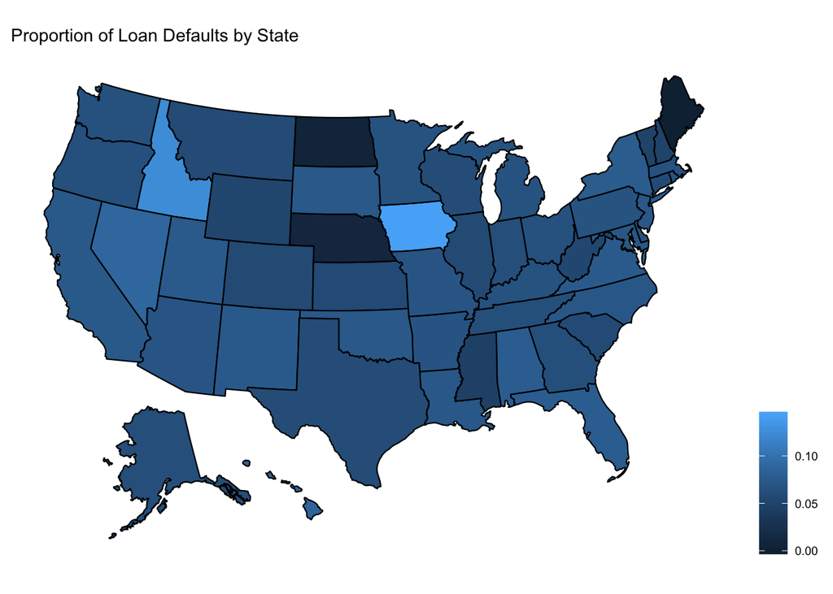

```r
state.dat  <- loan.dat %>%
  group_by(addr_state) %>%
  summarise(state.prop.default =  mean(loan_status_bin == "Bad", na.rm = TRUE),
            state.prop.gradeA = sum(grade_ordinal == 1)/n(),
            state.prop.gradeB = sum(grade_ordinal == 2)/n(),
            state.prop.gradeC = sum(grade_ordinal == 3)/n(),
            state.prop.gradeD = sum(grade_ordinal == 4)/n(),
            state.prop.gradeE = sum(grade_ordinal == 5)/n(),
            state.prop.gradeF = sum(grade_ordinal == 6)/n(),
            state.prop.gradeG = sum(grade_ordinal == 7)/n()) %>%
  mutate(state = addr_state)

#head(state.dat)

plot_usmap(data = state.dat, regions = "state", values = "state.prop.default") +
  scale_fill_continuous(name = "") +
  ggtitle("Proportion of Loan Defaults by State") +
  theme(legend.position = "right")
```

We see some variation from state to state, but did not observe regional trends which would allow us to collapse our states into a lower number of categories.

We also hypothesized that Debt-to-Income Ratio (DTI) might affect loan repayment, and examined the distribution of this variable.

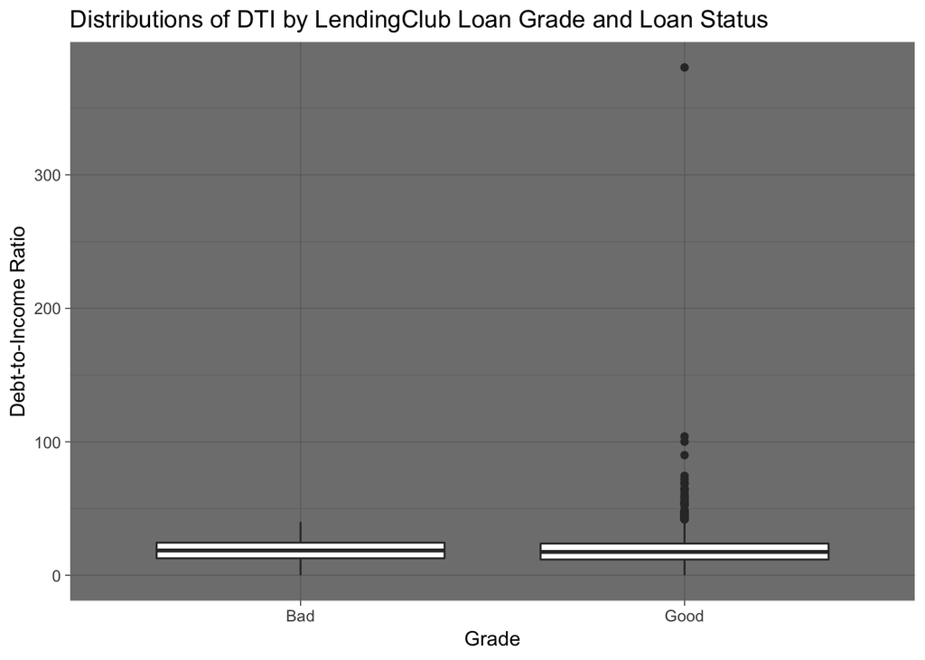

```r
loan.dat %>%
  filter(!is.na(loan_status_bin)) %>%
  ggplot() +
  geom_boxplot(aes(y = dti, x = loan_status_bin,color = grade_ordinal)) +
  scale_color_brewer(name = "LendingClub Grade",palette = "Blues") +
  theme_dark() +
  scale_y_continuous(name = "Debt-to-Income Ratio") +
  scale_x_discrete(name = "Grade") +
  ggtitle("Distributions of DTI by LendingClub Loan Grade and Loan Status")
```

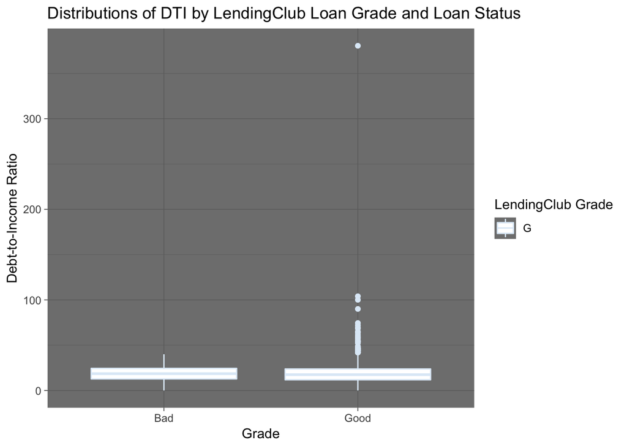

```r
#excluding 2 outliers
loan.dat %>%
  filter(dti < 7500 & !is.na(loan_status_bin)) %>%
  ggplot() +
  geom_boxplot(aes(y = dti, x = loan_status_bin,color = grade)) +
  scale_color_brewer(name = "LendingClub Grade",palette = "Blues") +
  theme_dark() +
  scale_y_continuous(name = "Debt-to-Income Ratio") +
  scale_x_discrete(name = "Grade") +
  ggtitle("Distributions of DTI by LendingClub Loan Grade and Loan Status")
```

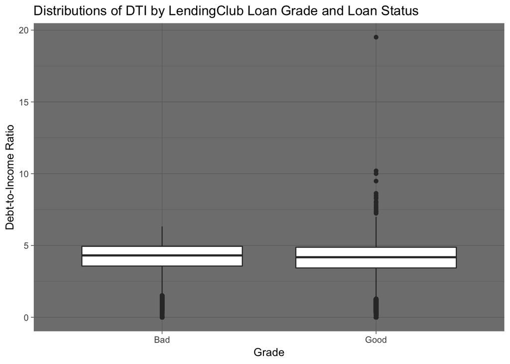

```r
#sqrt transform
loan.dat %>%
  filter(!is.na(loan_status_bin)) %>%
  ggplot() +
  geom_boxplot(aes(y = sqrt(dti), x = loan_status_bin,color = grade_ordinal)) +
  scale_color_brewer(name = "LendingClub Grade",palette = "Blues") +
  theme_dark() +
  scale_y_continuous(name = "Debt-to-Income Ratio") +
  scale_x_discrete(name = "Grade") +
  ggtitle("Distributions of DTI by LendingClub Loan Grade and Loan Status")
```

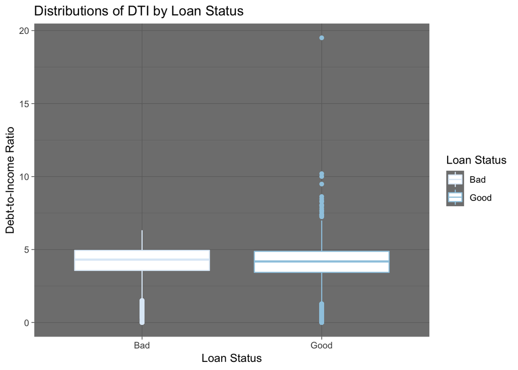

```r
#overall distribution
loan.dat %>%
  filter(!is.na(loan_status_bin)) %>%
  ggplot() +
  geom_boxplot(aes(y = sqrt(dti), x = loan_status_bin,color = loan_status_bin)) +
  scale_color_brewer(name = "Loan Status",palette = "Blues") +
  theme_dark() +
  scale_y_continuous(name = "Debt-to-Income Ratio") +
  scale_x_discrete(name = "Loan Status") +
  ggtitle("Distributions of DTI by Loan Status")
```

## Building the Prediction Model

In building our prediction model, we considered three different models*:  
1. Ridge  
2. Lasso  
3. Elastic Net

*Warning: Due to the large number of records and predictors, the models took a long time to train. The training time was approximately ~ 4 hours.

[output not shown]

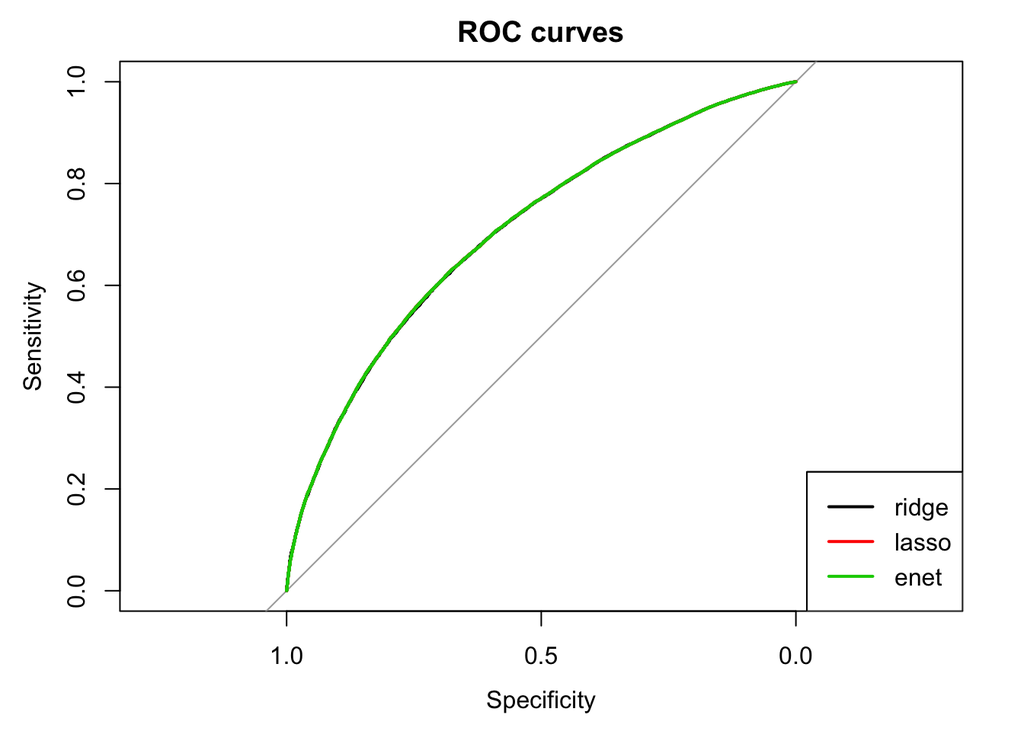

[output not shown]

```
##     ridge     lasso      enet
## 0.7073157 0.7077265 0.7077178
```

```r
setwd(set_dir)
load('./loan.dat.Rdata')
start_time <- Sys.time()

summary(loan.dat$loan_status_bin)
56958/769037 # only 7.4% of bad status

# This chunk takes a very very long time to run!!!
# I ran this overnight on my laptop and
# saved the results
# That's why eval is set to FALSE

# keep a fifth of the data set to assess test performance
set.seed(1)
test.indx <- sample(1:dim(loan.dat)[1], 200000, replace = FALSE)
train.indx <- setdiff(1:dim(loan.dat)[1], test.indx)

summary(loan.dat$loan_status_bin[test.indx])
summary(loan.dat$loan_status_bin[train.indx])

train.control = trainControl(method="repeatedcv", number=5, repeats=3,
                    classProbs=T, summaryFunction=twoClassSummary)

models = c("ridge", "lasso", "enet")
n_models = length(models)

AUC = rep(0,n_models)
names(AUC) = models
for (m in 1:n_models) {

    print_str <- paste("Training model: ",
                       models[m], sep='')
    print(print_str)

    # save our results
    if (models[m] == 'ridge'){

      fit = train(loan_status_bin ~.,
                  data=loan.dat[train.indx, ],
                  method="glmnet", metric="ROC", trControl=train.control,
                  tuneGrid=expand.grid(alpha = 0, lambda = .5 ^ (-20:20)))

      fit.ridge <- fit
    } else if (models[m] == 'lasso'){

      fit = train(loan_status_bin ~.,
                  data=loan.dat[train.indx, ],
                  method="glmnet", metric="ROC", trControl=train.control,
                  tuneGrid=expand.grid(alpha = 1, lambda = .5 ^ (-20:20)))

      fit.lasso <- fit
    } else if (models[m] == 'enet'){

      fit = train(loan_status_bin ~.,
                  data=loan.dat[train.indx, ],
                  method="glmnet", metric="ROC", trControl=train.control,
                  tuneGrid=expand.grid(alpha = seq(.05,.95,.05), lambda = .5 ^ (-20:20)))

      fit.enet <- fit
    } else if (models[m] == 'adaboost'){

      fit = train(loan_status_bin ~.,
            data=loan.dat[train.indx, ],
            method=models[m], metric="ROC", trControl=train.control)

      fit.adaboost <- fit

    } else if (models[m] == 'xgbTree'){

      fit = train(loan_status_bin ~.,
            data=loan.dat[train.indx, ],
            method=models[m], metric="ROC", trControl=train.control)

      fit.xgb <- fit

    } else if (models[m] == 'C5.0Cost'){

      fit = train(loan_status_bin ~.,
            data=loan.dat[train.indx, ],
            method=models[m], metric="ROC", trControl=train.control)

      fit.ccost <- fit

    } else if (models[m] == 'svmLinearWeights'){

      fit = train(loan_status_bin ~.,
            data=loan.dat[train.indx, ],
            method=models[m], metric="ROC", trControl=train.control)

      fit.svm <- fit

    } else('Unknown model type!')

    probs = predict(fit, loan.dat[test.indx,], type="prob")

    R = roc(loan.dat$loan_status_bin[test.indx], probs$Good)

    plot.roc(R, add=(m>1), col=m, lwd=2, main="ROC curves")

    legend("bottomright", legend=models, col=1:n_models, lwd=2)

    AUC[m] = R$auc
}
AUC

end_time <- Sys.time()
time <- end_time - start_time
time

setwd(set_dir)
save(fit.ridge, fit.lasso, fit.enet, file = "./models.RData")
```

The AUC for all three models were similar. However, lasso model (with $\alpha=1$ and $\lambda=0.0001220703$) had the largest AUC. Therefore, we decided to use the lasso model (with $\alpha=1$ and $\lambda=0.0001220703$) as our final model and retrained the it using these parameters with all data.

```r
x = model.matrix(loan_status_bin ~ ., loan.dat)[,-1]
y = loan.dat$loan_status_bin

final_mod = glmnet(x=x, y=y, family = 'binomial', alpha = 1,
                   lambda = 0.0001220703)


setwd(set_dir)
save(final_mod, file = "./final_model.RData")
```

## Results

Here is our final lasso model ($\alpha=1$ and $\lambda=0.0001220703$) with the following regression coefficients:

```r
setwd(set_dir)
#load("final_model.RData")
coef(final_mod)
```

```
## 92 x 1 sparse Matrix of class "dgCMatrix"
##                                               s0
## (Intercept)                         2.126283e+00
## loan_amnt                          -6.750296e-06
## funded_amnt                         .
## grade_ordinal                      -3.122226e-01
## emp_length_ordinal                  7.644084e-03
## home_ownershipMORTGAGE              2.317965e-03
## home_ownershipNONE                 -3.335335e-01
## home_ownershipOTHER                -5.775394e-01
## home_ownershipOWN                   .
## home_ownershipRENT                 -1.271860e-01
## annual_inc                          4.555097e-06
## verification_statusSource Verified  7.753753e-02
## verification_statusVerified        -1.087390e-01
## purposecredit_card                  1.577752e-01
## purposedebt_consolidation           .
## purposeeducational                 -4.108364e-01
## purposehome_improvement             .
## purposehouse                       -2.484775e-02
## purposemajor_purchase               .
## purposemedical                     -1.028531e-01
## purposemoving                      -2.943002e-02
## purposeother                       -3.470342e-02
## purposerenewable_energy            -1.101536e-01
## purposesmall_business              -5.684232e-01
## purposevacation                     2.839905e-02
## purposewedding                     -1.683520e-01
## addr_stateAL                       -1.177174e-01
## addr_stateAR                        .
## addr_stateAZ                       -3.691371e-02
## addr_stateCA                       -9.251343e-02
## addr_stateCO                        1.610975e-01
## addr_stateCT                        8.365280e-02
## addr_stateDC                        3.818644e-01
## addr_stateDE                        .
## addr_stateFL                       -1.531459e-01
## addr_stateGA                        1.720272e-02
## addr_stateHI                       -1.190482e-01
## addr_stateIA                       -8.190531e-02
```

[output cut: 39 more lines]

```
## delinq_2yrs                         1.155930e-02
## inq_last_6mths                     -1.828347e-01
## open_acc                            3.228885e-03
## pub_rec                             1.617830e-01
## revol_bal                           2.759894e-06
## revol_util                         -4.939832e-03
## total_acc                          -1.947432e-03
## initial_list_statusw                5.882670e-01
## application_typeJOINT               2.047160e+00
## acc_now_delinq                      .
## tot_coll_amt_gt0TRUE                1.816111e-01
## tot_cur_bal                         1.381133e-07
## total_rev_hi_lim                    .
## perc_funded_amnt_inv                1.315427e+00
## termShort                           3.201315e-03
```